# Simple NIMBLE model comparison of radiocarbon slopes

Kevan Edinborough

02 August 2026

# 1 Aim

This vignette compares two simple demographic slope models for the same Australian radiocarbon dataset over a user-defined calendar interval. The default interval is 2000–0 cal BP (approximately 50 BC–AD 1950), providing a substantial pre-colonial baseline as well as the colonial period:

1. **Single-slope model:** one exponential rate across the complete interval. In plain English, the radiocarbon-derived trajectory changes gradually at approximately one proportional rate; the data do not require a distinct break around colonisation.
2. **Change-point model:** one slope before and another after an estimated change point. In plain English, the trajectory changes at an estimated date; if the later slope is substantially more negative and the change-point interval overlaps sustained European occupation, the pattern is consistent with an acceleration during the colonial period.

The radiocarbon dates are calibrated with `rcarbon`. Site-time bins are used to reduce oversampling, and one median calibrated age is retained per bin. The two demographic models are fitted with the custom distributions supplied by `nimbleCarbon` and compared using WAIC.

> **Interpretive limit:** this is a model of the temporal distribution of archaeological radiocarbon evidence. It does not prove that European colonisation caused a demographic decline. A colonial interpretation requires the estimated change point and its uncertainty to be compared with independent historical evidence, while considering sampling, preservation, research intensity, land-use change, mobility and altered depositional practices.

# 2 1. Setup

```r
knitr::opts_chunk$set(
  echo = TRUE,
  message = TRUE,
  warning = TRUE,
  fig.width = 9,
  fig.height = 5.5
)

required <- c(
  "readxl", "dplyr", "ggplot2", "tibble", "tidyr",
  "rcarbon", "nimble", "nimbleCarbon", "coda", "knitr"
)

missing <- required[!vapply(required, requireNamespace, logical(1), quietly = TRUE)]
if (length(missing)) {
  stop(
    "Install the missing packages before knitting: ",
    paste(missing, collapse = ", "),
    "\nRun: install.packages(c(",
    paste(sprintf('"%s"', missing), collapse = ", "),
    "))"
  )
}

library(readxl)
library(dplyr)
library(ggplot2)
library(tibble)
library(tidyr)
library(rcarbon)
library(nimble)
library(nimbleCarbon)
library(coda)
library(knitr)

dir.create("output", showWarnings = FALSE, recursive = TRUE)

# -------------------------------------------------------------------------
# GLOBAL PARAMETERS
# Edit these in the YAML header at the top of this vignette.
# calendar_display = "calAD" or "calBP" controls tables and figure axes.
# parallel_cores = 1 runs sequentially; 2 runs the two model fits in parallel.
# Because this vignette compares only two models, values above 2 are capped at 2.
# Explicit MCMC values override the selected run_mode preset. Leave them null
# to use the test, medium, or long defaults.
# -------------------------------------------------------------------------

run_presets <- list(
  test   = list(niter = 3000,  nburnin = 1000,  thin = 4,  nchains = 2),
  medium = list(niter = 20000, nburnin = 7000,  thin = 10, nchains = 3),
  long   = list(niter = 80000, nburnin = 30000, thin = 20, nchains = 4)
)

run_mode <- tolower(params$run_mode)
if (!run_mode %in% names(run_presets)) {
  stop("run_mode must be 'test', 'medium', or 'long'.")
}

mcmc_cfg <- run_presets[[run_mode]]

resolve_positive_integer <- function(value, default, label, allow_zero = FALSE) {
  if (is.null(value) || length(value) == 0 || is.na(value)) return(as.integer(default))
  out <- suppressWarnings(as.integer(value))
  minimum <- if (allow_zero) 0L else 1L
  if (is.na(out) || out < minimum || out != as.numeric(value)) {
    stop(label, " must be a whole number of ", minimum, " or more, or null.")
  }
  out
}

mcmc_cfg$nchains <- resolve_positive_integer(params$mcmc_chains, mcmc_cfg$nchains, "mcmc_chains")
mcmc_cfg$niter <- resolve_positive_integer(params$mcmc_iterations, mcmc_cfg$niter, "mcmc_iterations")
mcmc_cfg$nburnin <- resolve_positive_integer(params$mcmc_burnin, mcmc_cfg$nburnin, "mcmc_burnin", allow_zero = TRUE)
mcmc_cfg$thin <- resolve_positive_integer(params$mcmc_thin, mcmc_cfg$thin, "mcmc_thin")
mcmc_cfg$seed <- resolve_positive_integer(params$mcmc_seed, 73021L, "mcmc_seed")

if (mcmc_cfg$nburnin >= mcmc_cfg$niter) {
  stop("mcmc_burnin must be smaller than mcmc_iterations.")
}
if ((mcmc_cfg$niter - mcmc_cfg$nburnin) %/% mcmc_cfg$thin < 50) {
  warning("Fewer than 50 posterior samples per chain will be retained. Increase iterations or reduce thinning.")
}

start_bp <- as.numeric(params$start_calbp)
end_bp <- as.numeric(params$end_calbp)
calendar_display <- tolower(as.character(params$calendar_display))
if (!calendar_display %in% c("calad", "calbp")) {
  stop("calendar_display must be 'calAD' or 'calBP'.")
}

bp_to_ad <- function(x) 1950 - x
calendar_axis_label <- if (calendar_display == "calad") "Calendar year AD" else "Calendar years BP"
calendar_values <- function(x) if (calendar_display == "calad") bp_to_ad(x) else x
calendar_scale <- if (calendar_display == "calbp") {
  ggplot2::scale_x_reverse(limits = c(start_bp, end_bp))
} else {
  ggplot2::scale_x_continuous(limits = sort(c(bp_to_ad(start_bp), bp_to_ad(end_bp))))
}

available_cores <- parallel::detectCores(logical = TRUE)
if (is.na(available_cores) || available_cores < 1) available_cores <- 1L
requested_cores <- suppressWarnings(as.integer(params$parallel_cores))
if (is.na(requested_cores) || requested_cores < 1L) {
  stop("parallel_cores must be a whole number of 1 or more.")
}
parallel_cores <- min(requested_cores, available_cores, 2L)
parallel_enabled <- parallel_cores > 1L

if (!is.finite(start_bp) || !is.finite(end_bp) || start_bp <= end_bp) {
  stop("start_calbp must be older/larger than end_calbp.")
}

set.seed(mcmc_cfg$seed)

configuration <- tibble(
  setting = c("Run mode", "Analysis start cal BP", "Analysis end cal BP",
              "Displayed calendar scale", "Displayed start", "Displayed end",
              "Calibration curve", "Iterations per chain", "Burn-in", "Thinning",
              "Chains", "MCMC seed", "Retained samples per chain",
              "Logical processors detected", "Processors requested",
              "Processors used", "Parallel model fitting"),
  value = c(run_mode, start_bp, end_bp, ifelse(calendar_display == "calad", "cal AD", "cal BP"),
            calendar_values(start_bp), calendar_values(end_bp), params$calibration_curve,
            mcmc_cfg$niter, mcmc_cfg$nburnin, mcmc_cfg$thin, mcmc_cfg$nchains,
            mcmc_cfg$seed, (mcmc_cfg$niter - mcmc_cfg$nburnin) %/% mcmc_cfg$thin,
            available_cores, requested_cores, parallel_cores, parallel_enabled)
)
knitr::kable(configuration)
```

| setting | value |
| --- | --- |
| Run mode | long |
| Analysis start cal BP | 2000 |
| Analysis end cal BP | 0 |
| Displayed calendar scale | cal AD |
| Displayed start | -50 |
| Displayed end | 1950 |
| Calibration curve | shcal20 |
| Iterations per chain | 80000 |
| Burn-in | 30000 |
| Thinning | 20 |
| Chains | 4 |
| MCMC seed | 73021 |
| Retained samples per chain | 2500 |
| Logical processors detected | 20 |
| Processors requested | 2 |
| Processors used | 2 |
| Parallel model fitting | TRUE |

```r
window_years <- start_bp - end_bp
window_start_ad <- bp_to_ad(start_bp)
window_end_ad <- bp_to_ad(end_bp)

cat("\n**Resolved model window:** ", start_bp, "–", end_bp, " cal BP (approximately ",
    window_start_ad, " to ", window_end_ad, " AD; ", window_years, " years).\n", sep = "")
```

```
##
## **Resolved model window:** 2000–0 cal BP (approximately -50 to 1950 AD; 2000 years).
```

```r
if (window_years < 800) {
  warning("The model window is shorter than 800 years. It may not provide enough pre-colonial baseline to identify the full curve or a stable change point.")
}
if (window_end_ad < 1788 || window_start_ad > 1850) {
  warning("The selected interval does not fully bracket the principal period of European colonisation. Review start_calbp and end_calbp.")
}
```

# 3 2. Import the same AusData dataset

```r
input_file <- "AusData.xlsx"
if (!file.exists(input_file)) {
  stop("AusData.xlsx is not in the project folder.")
}

raw <- readxl::read_excel(input_file, sheet = "AusData")
needed <- c("LabID", "SiteID", "C14Age", "C14Error")
missing_cols <- setdiff(needed, names(raw))
if (length(missing_cols)) {
  stop("Missing required columns: ", paste(missing_cols, collapse = ", "))
}

AUD <- raw |>
  transmute(
    lab_id = as.character(LabID),
    site_id = as.character(SiteID),
    c14_age = suppressWarnings(as.numeric(C14Age)),
    c14_error = suppressWarnings(as.numeric(C14Error))
  ) |>
  filter(
    !is.na(lab_id),
    !is.na(site_id),
    is.finite(c14_age),
    is.finite(c14_error),
    c14_error > 0
  ) |>
  mutate(
    # rcarbon requires every calibration ID to be unique. Laboratory IDs are
    # retained separately because replicate determinations can share a LabID.
    calibration_id = sprintf("AusDate_%05d", row_number())
  )

audit <- tibble(
  rows_in_workbook = nrow(raw),
  valid_dates = nrow(AUD),
  sites = n_distinct(AUD$site_id),
  median_error = median(AUD$c14_error)
)
knitr::kable(audit, digits = 1)
```

| rows_in_workbook | valid_dates | sites | median_error |
| --- | --- | --- | --- |
| 1214 | 1214 | 57 | 80 |

# 4 3. Calibrate and create independent site-time bins

```r
cal <- rcarbon::calibrate(
  x = AUD$c14_age,
  errors = AUD$c14_error,
  ids = AUD$calibration_id,
  calCurves = params$calibration_curve,
  normalised = FALSE,
  verbose = TRUE
)
```

```
## [1] "Calibrating radiocarbon ages..."
##   |                                                                              |                                                                      |   0%  |                                                                              |                                                         …
## [1] "Done."
```

```r
cal_summary <- as.data.frame(summary(cal))
if (!"MedianBP" %in% names(cal_summary)) {
  stop("The rcarbon calibration summary did not contain MedianBP.")
}

AUD$median_calbp <- suppressWarnings(as.numeric(cal_summary$MedianBP))

# Group same-site determinations that are close in conventional radiocarbon age.
AUD$bin_id <- rcarbon::binPrep(
  sites = AUD$site_id,
  ages = AUD$c14_age,
  h = 100
)

# One representative calendar estimate per site-time bin.
binned <- AUD |>
  filter(
    is.finite(median_calbp),
    median_calbp >= end_bp,
    median_calbp <= start_bp
  ) |>
  group_by(bin_id) |>
  summarise(
    theta = median(median_calbp),
    site_id = first(site_id),
    dates_in_bin = n(),
    .groups = "drop"
  ) |>
  arrange(desc(theta))

if (nrow(binned) < 20) {
  stop("Fewer than 20 site-time bins fall inside the selected analysis window.")
}

cat("Independent site-time bins used:", nrow(binned), "\n")
```

```
## Independent site-time bins used: 265
```

```r
cat("Original determinations represented:", sum(binned$dates_in_bin), "\n")
```

```
## Original determinations represented: 697
```

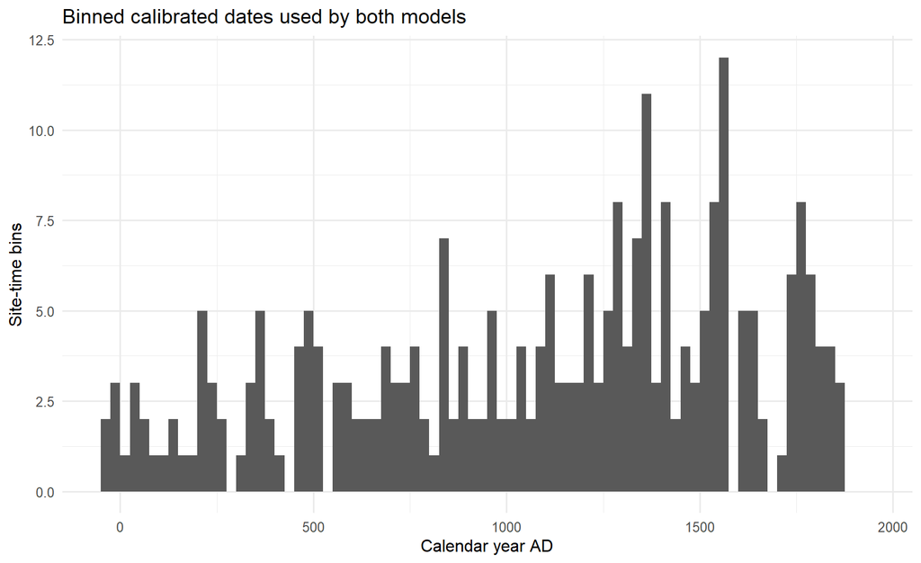

```r
write.csv(binned, "output/binned_calendar_dates.csv", row.names = FALSE)

binned_plot <- binned |> mutate(calendar_display_value = calendar_values(theta))

 ggplot(binned_plot, aes(calendar_display_value)) +
  geom_histogram(binwidth = 25, boundary = 0) +
  calendar_scale +
  labs(
    title = "Binned calibrated dates used by both models",
    x = calendar_axis_label,
    y = "Site-time bins"
  ) +
  theme_minimal(base_size = 12)
```

# 5 4. Define and explain the two nimbleCarbon models

The selected interval determines which part of the temporal curve the models can see. A window that begins too close to European occupation may omit the pre-colonial baseline and make the estimated slope or change point unstable. The default 2000-year window is deliberately broader.

**Model 1 — single slope:** assumes one proportional rate throughout the selected interval. If supported, the simplest reading is a broadly continuous trajectory without a clearly detectable change in rate.

**Model 2 — change point:** estimates an early slope, a later slope and the date separating them. If supported, it indicates that the trajectory changed rate, but the model does not itself identify the cause.

The sign and magnitude of the fitted rates are interpreted through the posterior model curves plotted below, avoiding confusion caused by the reversed cal BP time direction.

```r
theta <- binned$theta
N <- length(theta)

single_slope_code <- nimble::nimbleCode({
  r ~ dnorm(0, sd = 0.02)
  for (i in 1:N) {
    theta[i] ~ dExponentialGrowth(a = startBP, b = endBP, r = r)
  }
})

change_point_code <- nimble::nimbleCode({
  r_early ~ dnorm(0, sd = 0.02)
  r_late  ~ dnorm(0, sd = 0.02)
  mu ~ dunif(changeLow, changeHigh)
  for (i in 1:N) {
    theta[i] ~ dDoubleExponentialGrowth(
      a = startBP,
      b = endBP,
      r1 = r_early,
      r2 = r_late,
      mu = mu
    )
  }
})
```

# 6 5. Fit both models

```r
extract_numeric_waic <- function(x, depth = 0L) {
  # NIMBLE has returned WAIC in several different structures across versions:
  # numeric scalars, lists, S4/nimbleList objects and reference environments.
  # This recursive extractor handles those structures without coercing the
  # complete object blindly.
  if (is.null(x) || depth > 8L) return(NA_real_)

  if (is.numeric(x)) {
    out <- suppressWarnings(as.numeric(x))
    out <- out[is.finite(out)]
    return(if (length(out)) out[1] else NA_real_)
  }

  candidate_names <- c(
    "WAIC", "waic", "value", "totalWAIC", "WAICvalue",
    "waicValue", "WAIC_total", "total"
  )

  if (is.list(x)) {
    for (nm in intersect(candidate_names, names(x))) {
      out <- extract_numeric_waic(x[[nm]], depth + 1L)
      if (is.finite(out)) return(out)
    }
    for (element in x) {
      out <- extract_numeric_waic(element, depth + 1L)
      if (is.finite(out)) return(out)
    }
  }

  if (isS4(x)) {
    slots <- methods::slotNames(x)
    for (nm in intersect(candidate_names, slots)) {
      out <- extract_numeric_waic(methods::slot(x, nm), depth + 1L)
      if (is.finite(out)) return(out)
    }
    for (nm in slots) {
      value <- tryCatch(methods::slot(x, nm), error = function(e) NULL)
      out <- extract_numeric_waic(value, depth + 1L)
      if (is.finite(out)) return(out)
    }
  }

  if (is.environment(x)) {
    object_names <- tryCatch(ls(x, all.names = TRUE), error = function(e) character())
    for (nm in intersect(candidate_names, object_names)) {
      value <- tryCatch(get(nm, envir = x, inherits = FALSE), error = function(e) NULL)
      out <- extract_numeric_waic(value, depth + 1L)
      if (is.finite(out)) return(out)
    }
  }

  out <- tryCatch(
    suppressWarnings(as.numeric(x)),
    error = function(e) numeric(0)
  )
  out <- out[is.finite(out)]
  if (length(out)) out[1] else NA_real_
}

extract_fit <- function(x) {
  samples <- NULL
  waic_obj <- NULL

  if (is.list(x) && !is.null(x$samples)) {
    samples <- x$samples
    if (!is.null(x$WAIC)) waic_obj <- x$WAIC
    if (is.null(waic_obj) && !is.null(x$waic)) waic_obj <- x$waic
  } else {
    samples <- x
    waic_obj <- attr(x, "WAIC", exact = TRUE)
    if (is.null(waic_obj)) waic_obj <- attr(x, "waic", exact = TRUE)
  }

  list(
    samples = samples,
    WAIC = extract_numeric_waic(waic_obj),
    WAIC_raw = waic_obj
  )
}

# This self-contained worker reconstructs and fits one model. Keeping all model
# construction inside the worker makes the parallel route reliable on Windows,
# where PSOCK clusters start clean R sessions.
fit_one_model <- function(model_name, theta, start_bp, end_bp, mcmc_cfg) {
  suppressPackageStartupMessages({
    library(nimble)
    library(nimbleCarbon)
    library(coda)
  })

  N <- length(theta)
  constants_common <- list(N = N, startBP = start_bp, endBP = end_bp)
  data_common <- list(theta = theta)

  if (identical(model_name, "single")) {
    code <- nimble::nimbleCode({
      r ~ dnorm(0, sd = 0.02)
      for (i in 1:N) {
        theta[i] ~ dExponentialGrowth(a = startBP, b = endBP, r = r)
      }
    })

    inits <- lapply(seq_len(mcmc_cfg$nchains), function(ch) {
      set.seed(mcmc_cfg$seed + 100L + ch)
      list(r = rnorm(1, 0, 0.002))
    })

    return(nimble::nimbleMCMC(
      code = code, constants = constants_common, data = data_common,
      inits = inits, monitors = "r",
      niter = mcmc_cfg$niter, nburnin = mcmc_cfg$nburnin,
      thin = mcmc_cfg$thin, nchains = mcmc_cfg$nchains,
      setSeed = mcmc_cfg$seed + 1000L + seq_len(mcmc_cfg$nchains),
      samples = TRUE, samplesAsCodaMCMC = TRUE, summary = FALSE,
      WAIC = TRUE, progressBar = FALSE
    ))
  }

  if (identical(model_name, "change")) {
    code <- nimble::nimbleCode({
      r_early ~ dnorm(0, sd = 0.02)
      r_late  ~ dnorm(0, sd = 0.02)
      mu ~ dunif(changeLow, changeHigh)
      for (i in 1:N) {
        theta[i] ~ dDoubleExponentialGrowth(
          a = startBP, b = endBP, r1 = r_early, r2 = r_late, mu = mu
        )
      }
    })

    inits <- lapply(seq_len(mcmc_cfg$nchains), function(ch) {
      set.seed(mcmc_cfg$seed + 200L + ch)
      list(
        r_early = rnorm(1, 0, 0.002),
        r_late = rnorm(1, 0, 0.002),
        mu = runif(1, end_bp + 100, start_bp - 100)
      )
    })

    return(nimble::nimbleMCMC(
      code = code,
      constants = c(constants_common, list(
        changeLow = end_bp + 100, changeHigh = start_bp - 100
      )),
      data = data_common, inits = inits,
      monitors = c("r_early", "r_late", "mu"),
      niter = mcmc_cfg$niter, nburnin = mcmc_cfg$nburnin,
      thin = mcmc_cfg$thin, nchains = mcmc_cfg$nchains,
      setSeed = mcmc_cfg$seed + 2000L + seq_len(mcmc_cfg$nchains),
      samples = TRUE, samplesAsCodaMCMC = TRUE, summary = FALSE,
      WAIC = TRUE, progressBar = FALSE
    ))
  }

  stop("Unknown model name: ", model_name)
}

model_names <- c("single", "change")

if (parallel_enabled) {
  cat("Fitting the two models concurrently on", parallel_cores, "processors.
")
  cl <- parallel::makeCluster(parallel_cores)
  on.exit(parallel::stopCluster(cl), add = TRUE)
  parallel::clusterSetRNGStream(cl, iseed = mcmc_cfg$seed + 3000L)

  fits_raw <- parallel::parLapply(
    cl, model_names, fit_one_model,
    theta = theta, start_bp = start_bp, end_bp = end_bp, mcmc_cfg = mcmc_cfg
  )

  parallel::stopCluster(cl)
  on.exit(NULL, add = FALSE)
} else {
  cat("Fitting models sequentially on one processor.
")
  fits_raw <- lapply(
    model_names, fit_one_model,
    theta = theta, start_bp = start_bp, end_bp = end_bp, mcmc_cfg = mcmc_cfg
  )
}
```

```
## Fitting the two models concurrently on 2 processors.
```

```r
names(fits_raw) <- model_names
fit_single <- extract_fit(fits_raw$single)
fit_change <- extract_fit(fits_raw$change)

cat("Single-slope WAIC:", fit_single$WAIC, "\n")
```

```
## Single-slope WAIC: 4016.764
```

```r
cat("Change-point WAIC:", fit_change$WAIC, "\n")
```

```
## Change-point WAIC: 3992.216
```

```r
waic_available <- all(is.finite(c(fit_single$WAIC, fit_change$WAIC)))
if (!waic_available) {
  warning(
    paste(
      "WAIC could not be extracted from one or both NIMBLE results.",
      "The posterior models fitted successfully, but model ranking and",
      "winner-only graphics will be skipped rather than reporting a false winner."
    )
  )
}

saveRDS(fit_single, "output/fit_single_slope.rds")
saveRDS(fit_change, "output/fit_change_point.rds")
```

# 7 6. How to read the result

- If the **single-slope model** has clearly lower WAIC, the data favour one broad rate across the selected interval. This does not mean colonisation had no effect; it means a separate change in slope is not required by these radiocarbon data.
- If the **change-point model** has clearly lower WAIC, the data favour different early and late rates. A colonial interpretation becomes plausible only when the posterior change-point interval overlaps the historically relevant period and the later slope represents a stronger decline toward the present.
- If ΔWAIC is small, the dataset does not distinguish the two accounts reliably.

# 8 7. Model comparison

```r
if (waic_available) {
  comparison <- tibble(
    model = c("Single slope", "Change point: two slopes"),
    WAIC = c(fit_single$WAIC, fit_change$WAIC)
  ) |>
    arrange(WAIC) |>
    mutate(
      delta_WAIC = WAIC - min(WAIC),
      relative_likelihood = exp(-0.5 * delta_WAIC),
      WAIC_weight = relative_likelihood / sum(relative_likelihood),
      rank = row_number()
    )
} else {
  comparison <- tibble(
    model = c("Single slope", "Change point: two slopes"),
    WAIC = c(fit_single$WAIC, fit_change$WAIC),
    delta_WAIC = NA_real_,
    relative_likelihood = NA_real_,
    WAIC_weight = NA_real_,
    rank = NA_integer_
  )
}

knitr::kable(comparison, digits = 3)
```

| model | WAIC | delta_WAIC | relative_likelihood | WAIC_weight | rank |
| --- | --- | --- | --- | --- | --- |
| Change point: two slopes | 3992.216 | 0.000 | 1 | 1 | 1 |
| Single slope | 4016.764 | 24.548 | 0 | 0 | 2 |

```r
write.csv(comparison, "output/model_comparison_WAIC.csv", row.names = FALSE)

if (!waic_available) {
  cat("\n**WAIC comparison is unavailable in this run. No winning model is declared.**\n")
}
```

A lower WAIC indicates better expected out-of-sample predictive performance. A small WAIC difference means that the data do not strongly distinguish the two shapes.

# 9 8. Posterior summaries and diagnostics

```r
as_mcmc_list <- function(x) {
  if (inherits(x, "mcmc.list")) return(x)
  if (inherits(x, "mcmc")) return(coda::mcmc.list(x))
  if (is.list(x) && all(vapply(x, inherits, logical(1), "mcmc"))) {
    return(coda::mcmc.list(x))
  }
  stop("Posterior samples are not a coda mcmc or mcmc.list object.")
}

single_samples <- as_mcmc_list(fit_single$samples)
change_samples <- as_mcmc_list(fit_change$samples)

summarise_parameter <- function(samples, model_name) {
  mat <- as.matrix(samples)
  qs <- apply(mat, 2, quantile, probs = c(0.025, 0.5, 0.975))
  tibble(
    model = model_name,
    parameter = colnames(mat),
    mean = colMeans(mat),
    median = qs[2, ],
    lower_95 = qs[1, ],
    upper_95 = qs[3, ],
    effective_sample_size = as.numeric(coda::effectiveSize(samples))
  )
}

posterior_summary <- bind_rows(
  summarise_parameter(single_samples, "Single slope"),
  summarise_parameter(change_samples, "Change point")
)

knitr::kable(posterior_summary, digits = 5)
```

| model | parameter | mean | median | lower_95 | upper_95 | effective_sample_size |
| --- | --- | --- | --- | --- | --- | --- |
| Single slope | r | 0.00040 | 0.00041 | 0.00018 | 0.00060 | 307.18083 |
| Change point | mu | 150.40334 | 134.15046 | 102.60594 | 398.44109 | 40.67008 |
| Change point | r_early | 0.00062 | 0.00060 | 0.00038 | 0.00090 | 175.93018 |
| Change point | r_late | -0.02447 | -0.02369 | -0.04613 | -0.00328 | 118.86013 |

```r
write.csv(posterior_summary, "output/posterior_parameter_summary.csv", row.names = FALSE)

rhat_table <- function(samples, model_name) {
  if (length(samples) < 2) {
    return(tibble(model = model_name, parameter = varnames(samples), Rhat = NA_real_))
  }
  gd <- tryCatch(
    coda::gelman.diag(samples, autoburnin = FALSE, multivariate = FALSE)$psrf[, 1],
    error = function(e) rep(NA_real_, ncol(as.matrix(samples)))
  )
  tibble(model = model_name, parameter = names(gd), Rhat = as.numeric(gd))
}

convergence <- bind_rows(
  rhat_table(single_samples, "Single slope"),
  rhat_table(change_samples, "Change point")
)
knitr::kable(convergence, digits = 3)
```

| model | Rhat | parameter |
| --- | --- | --- |
| Single slope | 0.999 | NA |
| Change point | 1.098 | mu |
| Change point | 1.008 | r_early |
| Change point | 1.013 | r_late |

```r
write.csv(convergence, "output/convergence_Rhat.csv", row.names = FALSE)
```

# 10 9. Direct slope questions

```r
single_mat <- as.matrix(single_samples)
change_mat <- as.matrix(change_samples)

slope_questions <- tibble(
  quantity = c(
    "P(single rate < 0)",
    "P(early rate < 0)",
    "P(late rate < 0)",
    "P(late rate < early rate)",
    "Median change point cal BP",
    "95% lower change point cal BP",
    "95% upper change point cal BP",
    "Median change point cal AD",
    "95% lower change point cal AD",
    "95% upper change point cal AD"
  ),
  value = c(
    mean(single_mat[, "r"] < 0),
    mean(change_mat[, "r_early"] < 0),
    mean(change_mat[, "r_late"] < 0),
    mean(change_mat[, "r_late"] < change_mat[, "r_early"]),
    median(change_mat[, "mu"]),
    quantile(change_mat[, "mu"], 0.025),
    quantile(change_mat[, "mu"], 0.975),
    bp_to_ad(median(change_mat[, "mu"])),
    bp_to_ad(quantile(change_mat[, "mu"], 0.975)),
    bp_to_ad(quantile(change_mat[, "mu"], 0.025))
  )
)

knitr::kable(slope_questions, digits = 4)
```

| quantity | value |
| --- | --- |
| P(single rate < 0) | 0.0000 |
| P(early rate < 0) | 0.0000 |
| P(late rate < 0) | 1.0000 |
| P(late rate < early rate) | 1.0000 |
| Median change point cal BP | 134.1505 |
| 95% lower change point cal BP | 102.6059 |
| 95% upper change point cal BP | 398.4411 |
| Median change point cal AD | 1815.8495 |
| 95% lower change point cal AD | 1551.5589 |
| 95% upper change point cal AD | 1847.3941 |

```r
write.csv(slope_questions, "output/slope_probabilities.csv", row.names = FALSE)
```

# 11 10. Posterior slope-shape curves

The curves are evaluated from the actual `nimbleCarbon` probability distributions. They are normalised to integrate to one, so the plot compares shape rather than absolute population size.

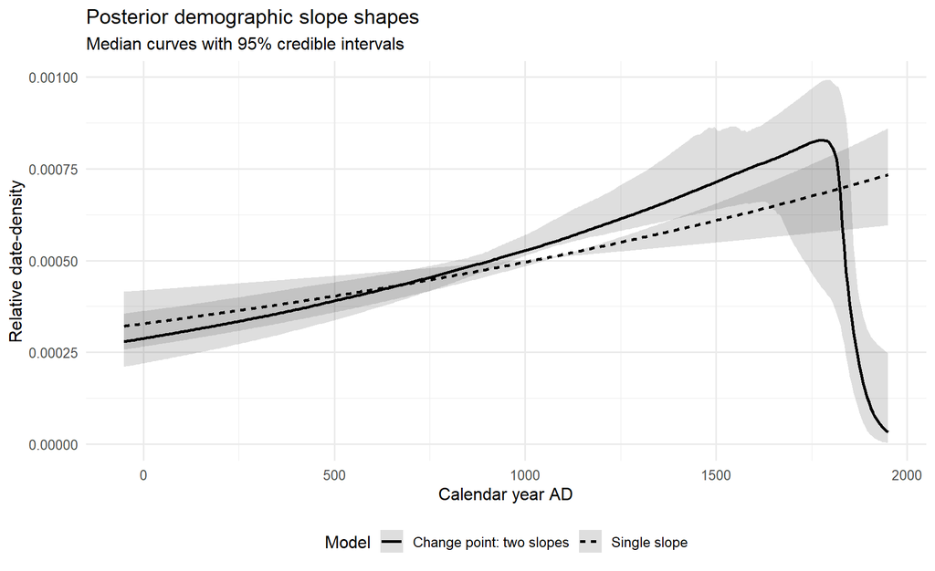

```r
grid_bp <- seq(start_bp, end_bp, by = -5)
years_toward_present <- start_bp - grid_bp

thin_draws <- function(mat, maximum = 1000) {
  if (nrow(mat) <= maximum) return(mat)
  mat[round(seq(1, nrow(mat), length.out = maximum)), , drop = FALSE]
}

single_draws <- thin_draws(single_mat)
change_draws <- thin_draws(change_mat)

single_curves <- t(apply(single_draws, 1, function(z) {
  nimbleCarbon::dExponentialGrowth(
    x = grid_bp,
    a = start_bp,
    b = end_bp,
    r = z["r"],
    log = FALSE
  )
}))

change_curves <- t(apply(change_draws, 1, function(z) {
  nimbleCarbon::dDoubleExponentialGrowth(
    x = grid_bp,
    a = start_bp,
    b = end_bp,
    r1 = z["r_early"],
    r2 = z["r_late"],
    mu = z["mu"],
    log = FALSE
  )
}))

curve_summary <- function(curves, model_name) {
  tibble(
    calBP = grid_bp,
    years_toward_present = years_toward_present,
    model = model_name,
    median = apply(curves, 2, median, na.rm = TRUE),
    lower = apply(curves, 2, quantile, 0.025, na.rm = TRUE),
    upper = apply(curves, 2, quantile, 0.975, na.rm = TRUE)
  )
}

curve_data <- bind_rows(
  curve_summary(single_curves, "Single slope"),
  curve_summary(change_curves, "Change point: two slopes")
) |>
  mutate(calendar_display_value = calendar_values(calBP))

write.csv(curve_data, "output/posterior_model_curves.csv", row.names = FALSE)

p_curve <- ggplot(curve_data, aes(calendar_display_value, median, linetype = model)) +
  geom_ribbon(aes(ymin = lower, ymax = upper, group = model), alpha = 0.16,
              inherit.aes = TRUE) +
  geom_line(linewidth = 0.9) +
  calendar_scale +
  labs(
    title = "Posterior demographic slope shapes",
    subtitle = "Median curves with 95% credible intervals",
    x = calendar_axis_label,
    y = "Relative date-density",
    linetype = "Model"
  ) +
  theme_minimal(base_size = 12) +
  theme(legend.position = "bottom")

p_curve
```

```r
ggsave("output/posterior_slope_shapes.png", p_curve, width = 9, height = 5.5, dpi = 300)
```

# 12 10. Numerical slope through time

Positive values mean that the fitted density rises as time moves toward the present; negative values mean that it declines toward the present.

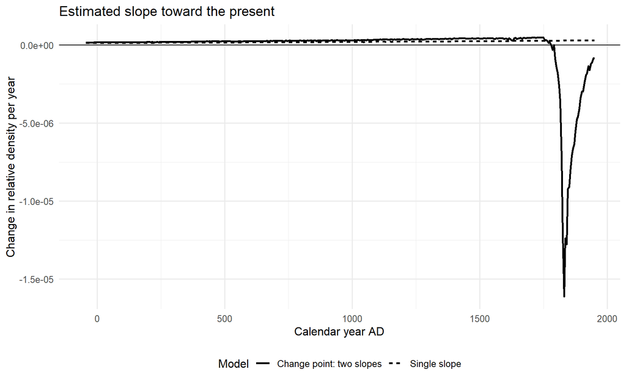

```r
curve_slopes <- curve_data |>
  group_by(model) |>
  arrange(years_toward_present, .by_group = TRUE) |>
  mutate(
    slope_toward_present = c(NA_real_, diff(median) / diff(years_toward_present))
  ) |>
  ungroup()

p_slope <- ggplot(curve_slopes, aes(calendar_display_value, slope_toward_present, linetype = model)) +
  geom_hline(yintercept = 0, linewidth = 0.4) +
  geom_line(linewidth = 0.9, na.rm = TRUE) +
  calendar_scale +
  labs(
    title = "Estimated slope toward the present",
    x = calendar_axis_label,
    y = "Change in relative density per year",
    linetype = "Model"
  ) +
  theme_minimal(base_size = 12) +
  theme(legend.position = "bottom")

p_slope
```

```r
ggsave("output/slope_toward_present.png", p_slope, width = 9, height = 5.5, dpi = 300)
write.csv(curve_slopes, "output/numerical_slopes.csv", row.names = FALSE)
```

# 13 11. Plain-language result

```r
if (!waic_available) {
  cat(
    "**WAIC model comparison is unavailable.** Both posterior models fitted, ",
    "but the WAIC values were not successfully extracted. The posterior ",
    "parameter results may still be inspected, but no best model should be ",
    "declared from this run."
  )
} else {
  best <- comparison$model[1]
  delta_second <- if (nrow(comparison) > 1) comparison$delta_WAIC[2] else NA_real_

  cat("**Best-supported model by WAIC:** ", best, ".  ", sep = "")
  cat("**WAIC difference to the other model:** ", round(delta_second, 2), ".  ", sep = "")

  if (best == "Change point: two slopes") {
    cat("The data support a change in slope rather than one constant rate.  ")
    cat("The median estimated change point is ",
        round(median(change_mat[, "mu"])), " cal BP (AD ",
        round(bp_to_ad(median(change_mat[, "mu"]))), ").  ", sep = "")
    cat("The posterior probability that the late slope is lower than the early slope is ",
        round(mean(change_mat[, "r_late"] < change_mat[, "r_early"]), 3), ".", sep = "")
  } else {
    cat("The more complex change-point model does not improve predictive fit sufficiently to displace the single-slope model.")
  }
}
```

**Best-supported model by WAIC:** Change point: two slopes. **WAIC difference to the other model:** 24.55. The data support a change in slope rather than one constant rate. The median estimated change point is 134 cal BP (AD 1816). The posterior probability that the late slope is lower than the early slope is 1.

# 14 12. Graphical model verdict

When WAIC is unavailable, this section is skipped automatically so the report cannot present an arbitrary model as the winner.

This final panel automatically selects the model with the lowest WAIC and presents the result as a concise visual summary. WAIC weights are relative measures of support between the two models fitted here; they are not absolute probabilities that either model is true.

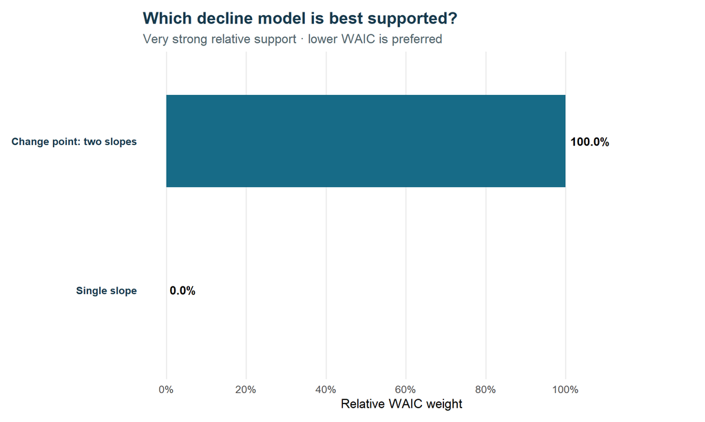

```r
# Consistent publication palette.
verdict_blue <- "#176B87"
verdict_dark <- "#183B4E"
verdict_gold <- "#D89B2B"
verdict_grey <- "#D9E1E5"
verdict_red  <- "#A63D40"

best_model <- comparison$model[1]
best_weight <- comparison$WAIC_weight[1]
best_delta <- if (nrow(comparison) > 1) comparison$delta_WAIC[2] else NA_real_

support_label <- dplyr::case_when(
  !is.finite(best_weight) ~ "WAIC unavailable",
  best_weight >= 0.90 ~ "Very strong relative support",
  best_weight >= 0.70 ~ "Strong relative support",
  best_weight >= 0.55 ~ "Moderate relative support",
  TRUE ~ "Models are difficult to distinguish"
)

# 12.1 Ranked relative model support
weight_plot_data <- comparison |>
  mutate(
    model = factor(model, levels = rev(model)),
    selected = as.character(model) == best_model,
    weight_percent = 100 * WAIC_weight
  )

p_weights <- ggplot(weight_plot_data, aes(WAIC_weight, model, fill = selected)) +
  geom_col(width = 0.62) +
  geom_text(
    aes(label = sprintf("%.1f%%", weight_percent)),
    hjust = -0.12,
    size = 4.2,
    fontface = "bold"
  ) +
  scale_fill_manual(values = c(`TRUE` = verdict_blue, `FALSE` = verdict_grey), guide = "none") +
  scale_x_continuous(
    limits = c(0, max(1.08, max(weight_plot_data$WAIC_weight, na.rm = TRUE) * 1.18)),
    breaks = seq(0, 1, 0.2),
    labels = function(x) paste0(round(100 * x), "%")
  ) +
  labs(
    title = "Which decline model is best supported?",
    subtitle = paste0(support_label, " · lower WAIC is preferred"),
    x = "Relative WAIC weight",
    y = NULL
  ) +
  theme_minimal(base_size = 13) +
  theme(
    plot.title = element_text(face = "bold", colour = verdict_dark, size = 17),
    plot.subtitle = element_text(colour = "#53656D"),
    panel.grid.major.y = element_blank(),
    panel.grid.minor = element_blank(),
    axis.text.y = element_text(face = "bold", colour = verdict_dark),
    plot.margin = margin(12, 45, 12, 12)
  )

p_weights
```

```r
ggsave("output/model_support_weights.png", p_weights, width = 9, height = 4.8, dpi = 320, bg = "white")
```

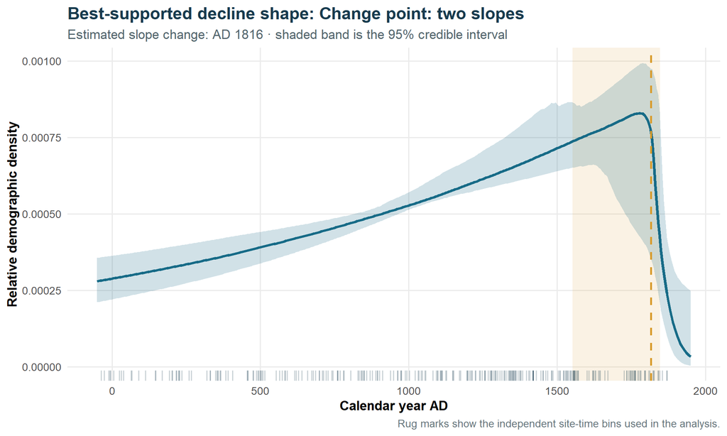

```r
winner_curve <- curve_data |>
  filter(model == best_model)

winner_slope <- curve_slopes |>
  filter(model == best_model)

# Posterior change-point interval is shown only when the two-slope model wins.
change_point_layer <- NULL
change_point_line <- NULL
change_point_text <- NULL

if (best_model == "Change point: two slopes") {
  mu_q <- quantile(change_mat[, "mu"], c(0.025, 0.5, 0.975), na.rm = TRUE)
  mu_display <- calendar_values(mu_q)
  change_point_layer <- annotate(
    "rect",
    xmin = min(mu_display[c(1, 3)]), xmax = max(mu_display[c(1, 3)]),
    ymin = -Inf, ymax = Inf,
    fill = verdict_gold, alpha = 0.13
  )
  change_point_line <- geom_vline(
    xintercept = mu_display[2],
    colour = verdict_gold,
    linewidth = 0.9,
    linetype = "dashed"
  )
  change_point_text <- paste0(
    "Estimated slope change: ",
    if (calendar_display == "calad") paste0("AD ", round(mu_display[2])) else paste0(round(mu_display[2]), " cal BP")
  )
} else {
  change_point_text <- "No change point is required by the best-supported model"
}

p_winner <- ggplot(winner_curve, aes(calendar_display_value, median)) +
  change_point_layer +
  geom_ribbon(aes(ymin = lower, ymax = upper), fill = verdict_blue, alpha = 0.20) +
  geom_line(colour = verdict_blue, linewidth = 1.25) +
  geom_rug(
    data = binned_plot,
    aes(x = calendar_display_value),
    inherit.aes = FALSE,
    sides = "b",
    alpha = 0.22,
    colour = verdict_dark
  ) +
  change_point_line +
  calendar_scale +
  labs(
    title = paste0("Best-supported decline shape: ", best_model),
    subtitle = paste0(change_point_text, " · shaded band is the 95% credible interval"),
    x = calendar_axis_label,
    y = "Relative demographic density",
    caption = "Rug marks show the independent site-time bins used in the analysis."
  ) +
  theme_minimal(base_size = 13) +
  theme(
    plot.title = element_text(face = "bold", colour = verdict_dark, size = 17),
    plot.subtitle = element_text(colour = "#53656D"),
    panel.grid.minor = element_blank(),
    axis.title = element_text(face = "bold"),
    plot.caption = element_text(colour = "#66757C")
  )

p_winner
```

```r
ggsave("output/best_model_posterior_curve.png", p_winner, width = 10, height = 5.8, dpi = 320, bg = "white")
```

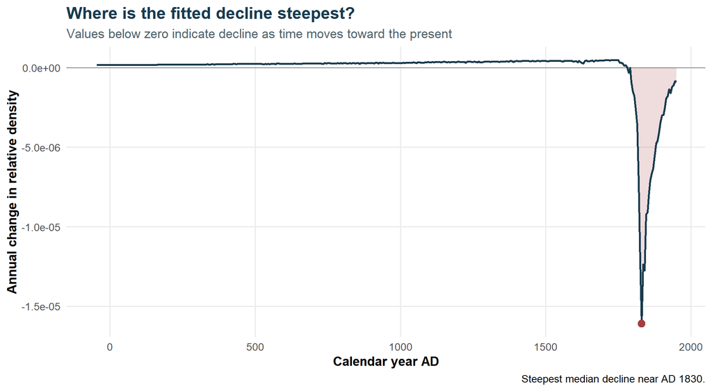

```r
# Identify the most negative median slope, i.e. the steepest fitted decline
# as chronology moves toward the present.
steepest_row <- winner_slope |>
  filter(is.finite(slope_toward_present)) |>
  slice_min(slope_toward_present, n = 1, with_ties = FALSE)

p_winner_slope <- ggplot(winner_slope, aes(calendar_display_value, slope_toward_present)) +
  geom_hline(yintercept = 0, colour = "#7C8B92", linewidth = 0.45) +
  geom_area(
    aes(y = ifelse(slope_toward_present < 0, slope_toward_present, 0)),
    fill = verdict_red,
    alpha = 0.18,
    na.rm = TRUE
  ) +
  geom_line(colour = verdict_dark, linewidth = 1.05, na.rm = TRUE) +
  geom_point(
    data = steepest_row,
    colour = verdict_red,
    size = 3.2
  ) +
  calendar_scale +
  labs(
    title = "Where is the fitted decline steepest?",
    subtitle = "Values below zero indicate decline as time moves toward the present",
    x = calendar_axis_label,
    y = "Annual change in relative density",
    caption = if (nrow(steepest_row)) paste0(
      "Steepest median decline near ",
      if (calendar_display == "calad") paste0("AD ", round(steepest_row$calendar_display_value)) else paste0(round(steepest_row$calendar_display_value), " cal BP"),
      "."
    ) else NULL
  ) +
  theme_minimal(base_size = 13) +
  theme(
    plot.title = element_text(face = "bold", colour = verdict_dark, size = 17),
    plot.subtitle = element_text(colour = "#53656D"),
    panel.grid.minor = element_blank(),
    axis.title = element_text(face = "bold")
  )

p_winner_slope
```

```r
ggsave("output/best_model_decline_slope.png", p_winner_slope, width = 10, height = 5.3, dpi = 320, bg = "white")
```

```r
# Compact conclusion card for the knitted HTML report.
if (best_model == "Change point: two slopes") {
  mu_median <- median(change_mat[, "mu"], na.rm = TRUE)
  late_steeper <- mean(change_mat[, "r_late"] < change_mat[, "r_early"], na.rm = TRUE)
  decline_statement <- paste0(
    "The two-slope model estimates a change near ",
    if (calendar_display == "calad") paste0("AD ", round(bp_to_ad(mu_median))) else paste0(round(mu_median), " cal BP"),
    ", with P(late slope < early slope) = ", sprintf("%.3f", late_steeper), "."
  )
} else {
  decline_statement <- paste0(
    "A single rate describes the selected interval more economically. ",
    "The posterior probability that its fitted rate is below zero is ",
    sprintf("%.3f", mean(single_mat[, "r"] < 0, na.rm = TRUE)), "."
  )
}

cat(sprintf(
  '<div style="border-left:8px solid %s;background:#F4F8FA;padding:18px 22px;margin:20px 0;border-radius:7px;box-shadow:0 2px 7px rgba(0,0,0,0.08);">\n<h3 style="margin-top:0;color:%s;">Model verdict</h3>\n<p style="font-size:1.12em;"><strong>%s</strong></p>\n<p><strong>Relative WAIC weight:</strong> %.1f%% &nbsp; | &nbsp; <strong>WAIC separation:</strong> %.2f</p>\n<p>%s</p>\n<p style="margin-bottom:0;color:#596970;"><em>%s</em></p>\n</div>',
  verdict_blue, verdict_dark, best_model, 100 * best_weight, best_delta,
  decline_statement, support_label
))
```

### Model verdict

**Change point: two slopes**

**Relative WAIC weight:** 100.0% | **WAIC separation:** 24.55

The two-slope model estimates a change near AD 1816, with P(late slope < early slope) = 1.000.

*Very strong relative support*

The three graphical outputs are saved at 320 dpi in the `output` folder:

- `model_support_weights.png`
- `best_model_posterior_curve.png`
- `best_model_decline_slope.png`